# Projeto 2

Neste projeto iremos analisar o dataset do Titanic. Tentaremos responder as seguintes questões:  
1) Qual a porcentagem de vítimas do acidente?  
2) Qual a porcentagem de vítimas masculinas?  
3) Qual a porcentagem de vítimas femininas?  
4) Qual a proporção de vítimas do sexo masculino?  
5) Qual a proporção de vítimas do sexo feminino?  
6) Qual a proporção de sobreviventes por sexo em cada classe?  
7) Há indícios que a idade, o sexo e a classe dos tripulantes foram variáveis que influenciaram entre sobreviver e morrer no titanic?

A última sessão deste documento conterá as respostas e conclusões após as fases de análise de dados.

```python
import pandas as pd
from pandas import Series,DataFrame
import numpy as np
import matplotlib.pyplot as plt
import seaborn as sns
%matplotlib inline
from __future__ import division
```

```python
df_titanic = pd.read_csv('titanic_data.csv')
```

```python
df_titanic.head()
```

|  | PassengerId | Survived | Pclass | Name | Sex | Age | SibSp | Parch | Ticket | Fare | Cabin | Embarked |
| --- | --- | --- | --- | --- | --- | --- | --- | --- | --- | --- | --- | --- |
| 0 | 1 | 0 | 3 | Braund, Mr. Owen Harris | male | 22.0 | 1 | 0 | A/5 21171 | 7.2500 | NaN | S |
| 1 | 2 | 1 | 1 | Cumings, Mrs. John Bradley (Florence Briggs Th... | female | 38.0 | 1 | 0 | PC 17599 | 71.2833 | C85 | C |
| 2 | 3 | 1 | 3 | Heikkinen, Miss. Laina | female | 26.0 | 0 | 0 | STON/O2. 3101282 | 7.9250 | NaN | S |
| 3 | 4 | 1 | 1 | Futrelle, Mrs. Jacques Heath (Lily May Peel) | female | 35.0 | 1 | 0 | 113803 | 53.1000 | C123 | S |
| 4 | 5 | 0 | 3 | Allen, Mr. William Henry | male | 35.0 | 0 | 0 | 373450 | 8.0500 | NaN | S |

```python
# Verificar o número de registros no dataframe carregado com dados do csv
len(df_titanic)
```

```
891
```

```python
# Verificar a consistência dos dados. Aqui quero saber se os dados das colunas estão preenchidos para cada linha
# ou se há dados ausentes
df_titanic.count()
```

```
PassengerId    891
Survived       891
Pclass         891
Name           891
Sex            891
Age            714
SibSp          891
Parch          891
Ticket         891
Fare           891
Cabin          204
Embarked       889
dtype: int64
```

```python
# Removo linhas sem informação de idade e de passageiros sem informação de embarque
clean_titanic = df_titanic[df_titanic['Age'].notnull()]
clean_titanic = clean_titanic[clean_titanic['Embarked'].notnull()]
clean_titanic.count()
```

```
PassengerId    712
Survived       712
Pclass         712
Name           712
Sex            712
Age            712
SibSp          712
Parch          712
Ticket         712
Fare           712
Cabin          183
Embarked       712
dtype: int64
```

```python
# Faço uma cópia do dataframe limpo
work_titanic = clean_titanic.copy()
# Substituo o valor da coluna "Survived" para ficar mais intuitivo
work_titanic.replace({"Survived": {0: "Nao", 1: "Sim"}}, inplace=True)
work_titanic.head()
```

|  | PassengerId | Survived | Pclass | Name | Sex | Age | SibSp | Parch | Ticket | Fare | Cabin | Embarked |
| --- | --- | --- | --- | --- | --- | --- | --- | --- | --- | --- | --- | --- |
| 0 | 1 | Nao | 3 | Braund, Mr. Owen Harris | male | 22.0 | 1 | 0 | A/5 21171 | 7.2500 | NaN | S |
| 1 | 2 | Sim | 1 | Cumings, Mrs. John Bradley (Florence Briggs Th... | female | 38.0 | 1 | 0 | PC 17599 | 71.2833 | C85 | C |
| 2 | 3 | Sim | 3 | Heikkinen, Miss. Laina | female | 26.0 | 0 | 0 | STON/O2. 3101282 | 7.9250 | NaN | S |
| 3 | 4 | Sim | 1 | Futrelle, Mrs. Jacques Heath (Lily May Peel) | female | 35.0 | 1 | 0 | 113803 | 53.1000 | C123 | S |
| 4 | 5 | Nao | 3 | Allen, Mr. William Henry | male | 35.0 | 0 | 0 | 373450 | 8.0500 | NaN | S |

```python
#Porcentagem de vítimas do acidente
victims = len(work_titanic[work_titanic.Survived=='Nao'])
total_passengers = len(work_titanic['Survived'])
print(victims / total_passengers)*100
```

```
59.5505617978
```

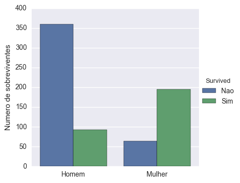

```python
# Distribuição de vítimas por sexo
g=sns.factorplot('Sex',data=work_titanic,hue='Survived', kind='count')
(g.set_axis_labels("", "Numero de sobreviventes")
  .set_xticklabels(["Homem", "Mulher"])
   .set_titles("{col_name} {col_var}")
   .despine(left=True))
```

```python
#Porcentagem de vítimas masculinas e femininas
male_victims = len(work_titanic[(work_titanic.Sex=='male') & (work_titanic.Survived=='Nao')])
print "Vítimas Masculinas: {}%".format((male_victims / victims)*100)
print "Vítimas Femininas: {}%".format(100-((male_victims / victims)*100))
```

```
Vítimas Masculinas: 84.9056603774%
Vítimas Femininas: 15.0943396226%
```

```python
#Porcentagem de vitimas masculinas vs passageiros masculinos
male_total = len(work_titanic[work_titanic.Sex=='male'])
print "Vítimas masculinas x Homens embarcados: {}%".format((male_victims/male_total)*100)
```

```
Vítimas masculinas x Homens embarcados: 79.4701986755%
```

```python
#Porcentagem de vitimas femininas vs passageiras femininas
female_total = len(work_titanic[work_titanic.Sex=='female'])
female_victims = len(work_titanic[(work_titanic.Sex=='female') & (work_titanic.Survived=='Nao')])
print "Vítimas femininas x Mulheres embarcadas: {}%".format((female_victims/female_total)*100)
```

```
Vítimas femininas x Mulheres embarcadas: 24.7104247104%
```

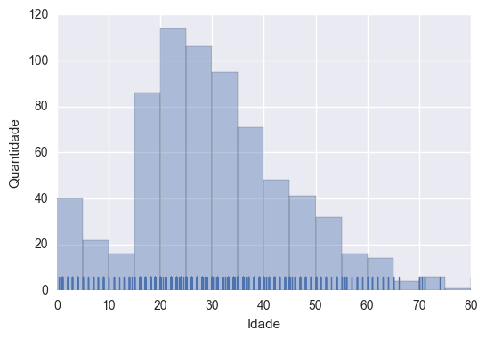

```python
# Distribuição de passageiros embarcados por idade
sns.distplot(work_titanic['Age'], bins=[0,5,10,15,20,25,30,35,40,45,50,55,60,65,70,75,80], kde=False, rug=True)
plt.ylabel('Quantidade')
plt.xlabel('Idade')
```

```python
# Adicionando uma coluna para identificar crianças
def criancas(passageiro):
    age,sex = passageiro
    if age < 16:
        return 'child'
    else:
        return sex


# Criando uma coluna para identificar adultos do sexo masculino, adultos do sexo feminino e crianças
# independente de sexo
work_titanic['Genre'] = work_titanic[['Age','Sex']].apply(criancas,axis=1)
```

```python
work_titanic.head()
```

|  | PassengerId | Survived | Pclass | Name | Sex | Age | SibSp | Parch | Ticket | Fare | Cabin | Embarked | Genre |
| --- | --- | --- | --- | --- | --- | --- | --- | --- | --- | --- | --- | --- | --- |
| 0 | 1 | Nao | 3 | Braund, Mr. Owen Harris | male | 22.0 | 1 | 0 | A/5 21171 | 7.2500 | NaN | S | male |
| 1 | 2 | Sim | 1 | Cumings, Mrs. John Bradley (Florence Briggs Th... | female | 38.0 | 1 | 0 | PC 17599 | 71.2833 | C85 | C | female |
| 2 | 3 | Sim | 3 | Heikkinen, Miss. Laina | female | 26.0 | 0 | 0 | STON/O2. 3101282 | 7.9250 | NaN | S | female |
| 3 | 4 | Sim | 1 | Futrelle, Mrs. Jacques Heath (Lily May Peel) | female | 35.0 | 1 | 0 | 113803 | 53.1000 | C123 | S | female |
| 4 | 5 | Nao | 3 | Allen, Mr. William Henry | male | 35.0 | 0 | 0 | 373450 | 8.0500 | NaN | S | male |

```python
# Criando uma matriz de sobreviventes por genero e classe
def survived_percentage_per_class_and_genre(ptitanic, pgenre, pclass):
    total = len(work_titanic[(ptitanic.Genre==pgenre)
                             &(ptitanic.Pclass==pclass)])
    total_survived = len(work_titanic[(ptitanic.Genre==pgenre)
                             &(ptitanic.Pclass==pclass)
                             &(ptitanic.Survived=='Sim')])
    return total_survived/total*100
```

```python
# Montando o dataframe com os dados calculados pela função definida acima
index_genres = work_titanic.Genre.unique()
column_classes = sorted(work_titanic.Pclass.unique())
percentage = []
for gen in index_genres:
    for cl in column_classes:
        percentage.append(survived_percentage_per_class_and_genre(work_titanic, gen,cl))
```

```python
df_survived_by_class_and_genre = DataFrame(np.reshape(percentage,(3,3)),
                                          index=pd.Index(index_genres),
                                          columns=pd.Index(column_classes))
df_survived_by_class_and_genre
```

|  | 1 | 2 | 3 |
| --- | --- | --- | --- |
| male | 37.755102 | 6.666667 | 12.888889 |
| female | 97.500000 | 90.625000 | 43.055556 |
| child | 83.333333 | 100.000000 | 43.103448 |

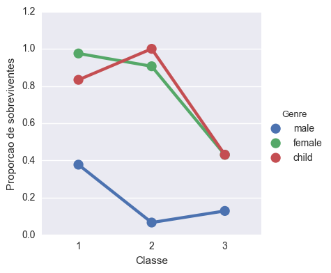

```python
# Representação gráfica do dataframe criado acima
def survivor_prop():
    sns.factorplot('Pclass','Survived',hue='Genre',data=work_titanic.replace({"Survived": {"Nao":0, "Sim":1}}), ci=None)
    plt.ylabel('Proporcao de sobreviventes')
    plt.xlabel('Classe')

survivor_prop()
```

# Resumo

Abaixo temos um resumo de tudo que analisamos com os dados disponíveis do acidente do Titanic. Os dados não são definitivamente conclusivos mas nos dá alguns indícios que serão apontados durante o resumo. Vamos às respostas:

1) Qual a porcentagem de vítimas do acidente?  
Após a limpeza dos dados contávamos com 712 passageiros embarcados. Destes, 59.55% vieram a ser vítimas do acidente.

2) Qual a porcentagem de vítimas masculinas?  
Do total de vítimas, 84.90% eram do sexo masculino.

3) Qual porcentagem de vítimas femininas?  
Do total de vítimas, 15.09% eram do sexo feminino.

4) Qual a proporção de vítimas do sexo masculino?  
De todos os passageiros embarcados do sexo masculino, 79.47% vieram a ser vítimas do acidente.

5) Qual a proporção de vítimas do sexo feminino?  
De todos os passageiros embarcados do sexo feminino, 24.71% vieram a ser vítimas do acidente.

6) Qual a proporção de sobreviventes por sexo em cada classe?  
A tabela abaixo mostra a porcentagem de sobreviventes em cada classe.

```python
df_survived_by_class_and_genre
```

|  | 1 | 2 | 3 |
| --- | --- | --- | --- |
| male | 37.755102 | 6.666667 | 12.888889 |
| female | 97.500000 | 90.625000 | 43.055556 |
| child | 83.333333 | 100.000000 | 43.103448 |

A mesma informação pode ser visualizada no gráfico:

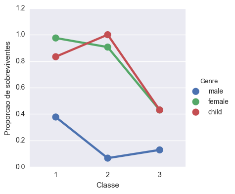

```python
survivor_prop()
```

Outra visualização da mesma informação encontra-se no gráfico abaixo:

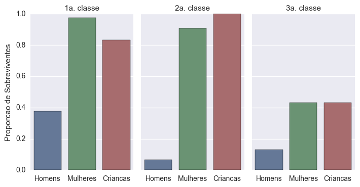

```python
def nome_classe(classe):
    if classe==1:
        return '1a. classe'
    if classe==2:
        return '2a. classe'
    if classe==3:
        return '3a. classe'

work_titanic['classe'] = work_titanic['Pclass'].apply(nome_classe)

g = sns.factorplot(x="Genre", y="Survived", col="classe", col_order=['1a. classe', '2a. classe', '3a. classe'],
                    data=work_titanic.replace({"Survived": {"Nao":0, "Sim":1}}), saturation=.5,
                    kind="bar", ci=None, aspect=.6)
(g.set_axis_labels("", "Proporcao de Sobreviventes")
   .set_xticklabels(["Homens", "Mulheres", "Criancas"])
   .set_titles("{col_name}")
   .set(ylim=(0, 1))
   .despine(left=True))
```

7) Há indícios que a idade, o sexo e a classe dos tripulantes foram variáveis que influenciaram entre sobreviver e morrer no titanic?  
Por qualquer ângulo que se olhe, os homens tiveram uma incidência de mortes maior que mulheres e crianças. Excluindo as crianças, aparentemente a classe mais alta (Pclass=1) teve uma incidência de sobreviventes maior que das outras classes.  
Como afirmado acima, estes dados não são definitivamente conclusivos, sendo necessários novos testes estatísticos, mas temos um forte indício que o sexo e idade foram fatores determinantes entre sobreviver ou não ao acidente.

# Referências:

http://nbviewer.jupyter.org/github/jmportilla/Udemy-notes/tree/master/

https://www.zeppelinhub.com/viewer/notebooks/bm90ZTovL2J1c3Rpb3MvbG9jYWwvYmI0Y2EwNjVkMTI1NDY2Y2EzNTIzNThiZjViYzIxOWQvbm90ZS5qc29u

https://seaborn.github.io/